# Time Series Forecasting Using ARIMA/SARIMA, ETS, RandomForest And LSTM Model

## Stock Market

### A. Introduction

#### 1. Time Series Forecasting

> - Time series forecasting is the process of using statistical models to predict future values of a time series based on past results.
> - Forecasting a time series can be divided into two types:

>   ```
>   If you use previous values of a time series to predict its future values, it is called Univariate Time Series Forecasting.
>
>   If you use predictors other than the series (such as exogenous variables) to forecast, it is called Multivariate Time Series Forecasting.
>   ```

> - This code focuses on a specific type of forecasting method called the ARIMA model.

#### 2. ARIMA Model

errors. The equation can be used to forecast future values. Any ‘non-seasonal’ time series that exhibits patterns and is not a random white noise can be modeled with ARIMA models.

> - So, ARIMA, short for AutoRegressive Integrated Moving Average, is a forecasting algorithm based on the idea that the information in the past values of the time series can alone be used to predict the future values.
> - ARIMA Models are specified by three order parameters: (p, d, q), where:

>   ```
>    p is the order of the AR term
>
>    q is the order of the MA term
>
>    d is the number of differencing required to make the time series stationary
>   ```

> - AR(p) Autoregression – a regression model that utilizes the dependent relationship between a current observation and observations over a previous period. An auto regressive (AR(p)) component refers to the use of past values in the regression equation for the time series.
> - I(d) Integration – uses differencing of observations (subtracting an observation from observation at the previous time step) in order to make the time series stationary. Differencing involves the subtraction of the current values of a series with its previous values d number of times.
> - MA(q) Moving Average – a model that uses the dependency between an observation and a residual error from a moving average model applied to lagged observations. A moving average component depicts the error of the model as a combination of previous error terms. The order q represents the number of terms to be included in the model.

> Types of ARIMA Model:

> ```
>   ARIMA : Non-seasonal Autoregressive Integrated Moving Averages
>
>   SARIMA : Seasonal ARIMA
>
>   SARIMAX : Seasonal ARIMA with exogenous variables
> ```

> If a time series, has seasonal patterns, then we need to add seasonal terms and it becomes SARIMA, short for Seasonal ARIMA.

### B. Time Series Forecasting

#### 1. Import Library

```python
import os
import warnings
warnings.filterwarnings('ignore')
import numpy as np
import pandas as pd
import matplotlib.pyplot as plt
plt.style.use('fivethirtyeight')
from pylab import rcParams
rcParams['figure.figsize'] = 15,8
from statsmodels.tsa.stattools import adfuller
from statsmodels.tsa.seasonal import seasonal_decompose
from statsmodels.tsa.arima_model import ARIMA
from pmdarima.arima import auto_arima
from sklearn.metrics import mean_squared_error, mean_absolute_error
import seaborn as sns
import math
import statsmodels.api as sm
import statsmodels.tsa.api as smt
import statsmodels.formula.api as smf
from statsmodels.tsa.statespace.sarimax import SARIMAX
from statsmodels.tsa.holtwinters import ExponentialSmoothing, SimpleExpSmoothing, Holt
from sklearn.ensemble import RandomForestRegressor
import tensorflow as tf
from tensorflow.keras import Sequential
from tensorflow.keras.layers import Dense, LSTM
```

#### 2. Load Data

> This data is private so we cannot make it public to you.

```python
stock = pd.read_csv('a.us.csv')
stock['Date'] = pd.to_datetime(stock['Date'])
stock.set_index('Date', inplace=True)
stock.head(10)
```

| Date | Open | High | Low | Close | Volume | OpenInt |
| --- | --- | --- | --- | --- | --- | --- |
| 1999-11-18 | 30.713 | 33.754 | 27.002 | 29.702 | 66277506 | 0 |
| 1999-11-19 | 28.986 | 29.027 | 26.872 | 27.257 | 16142920 | 0 |
| 1999-11-22 | 27.886 | 29.702 | 27.044 | 29.702 | 6970266 | 0 |
| 1999-11-23 | 28.688 | 29.446 | 27.002 | 27.002 | 6332082 | 0 |
| 1999-11-24 | 27.083 | 28.309 | 27.002 | 27.717 | 5132147 | 0 |
| 1999-11-26 | 27.594 | 28.012 | 27.509 | 27.807 | 1832635 | 0 |
| 1999-11-29 | 27.676 | 28.650 | 27.380 | 28.432 | 4317826 | 0 |
| 1999-11-30 | 28.350 | 28.986 | 27.634 | 28.480 | 4567146 | 0 |
| 1999-12-01 | 28.480 | 29.324 | 28.273 | 28.986 | 3133746 | 0 |
| 1999-12-02 | 29.532 | 30.375 | 29.155 | 29.786 | 3252997 | 0 |

#### 3. Transform Data & Visualization

> We only work with "Closing Price" and predict it.

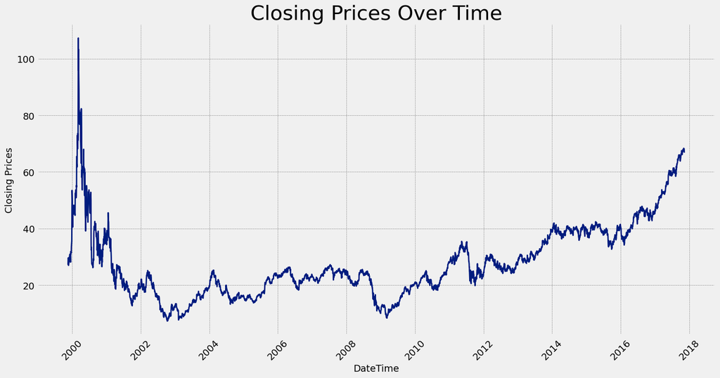

```python
sns.set_palette("dark")
plt.figure(figsize=(15, 8))
plt.grid(True, linestyle="--", linewidth=0.5, color="gray")
plt.xlabel("DateTime", fontsize=14,color='black')
plt.ylabel("Closing Prices", fontsize=14,color='black')
plt.plot(stock["Close"], linewidth=2, markersize=5)
plt.title("Closing Prices Over Time", fontsize=30,color='black')
plt.xticks(rotation=45)
plt.tight_layout()
plt.show()
```

```python
#Resample the data as it contains too much variations
# Aggregate by month and average stock prices in each month
ts_m = stock['Close'].resample('M').mean()
df = ts_m
```

> Resample by Week and then forecasting

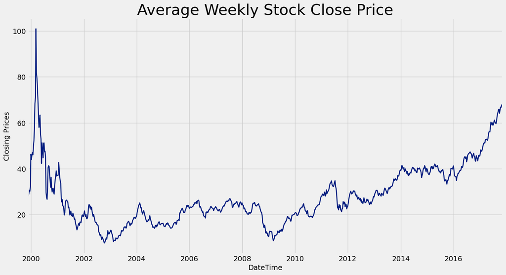

```python
#Resample the data as it contains too much variations
# Aggregate by week and average stock prices in each week
ts_week = stock['Close'].resample('W').mean()
# Draw charts
plt.figure(figsize=(15, 8))
ts_week.plot(linewidth=2, markersize=5)
plt.xlabel("DateTime", fontsize=14)
plt.ylabel("Closing Prices", fontsize=14)
plt.title("Average Weekly Stock Close Price", fontsize=30)
plt.show(1)
```

> Check Stationary from the data !

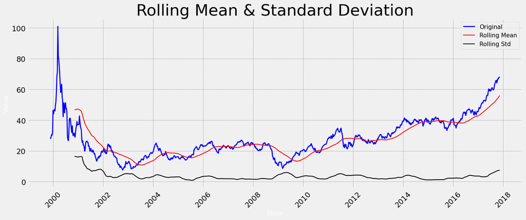

```
Results of Dickey-Fuller Test:
Test Statistic                  -0.497938
p-value                          0.892418
#Lags Used                      22.000000
Number of Observations Used    916.000000
Critical Value (1%)             -3.437509
Critical Value (5%)             -2.864700
Critical Value (10%)            -2.568453
dtype: float64
```

```python
def test_stationarity(timeseries):
    rolmean = timeseries.rolling(window=52, center=False).mean()
    rolstd = timeseries.rolling(window=52, center=False).std()
    plt.figure(figsize=(14, 6))
    plt.plot(timeseries, color="Blue", label="Original", linewidth=2)
    plt.plot(rolmean, color="Red", label="Rolling Mean", linewidth=1.5)
    plt.plot(rolstd, color="Black", label="Rolling Std", linewidth=1.5)
    plt.grid(True, linestyle="--", linewidth=0.5, color="gray")
    plt.xlabel("Date", fontsize=12, color="white")
    plt.ylabel("Value", fontsize=12, color="white")
    plt.title("Rolling Mean & Standard Deviation", fontsize=30)
    plt.legend(loc="best", fontsize=11)
    plt.xticks(rotation=45)
    plt.tight_layout()
    plt.show()

    print("\nResults of Dickey-Fuller Test:")
    dftest = adfuller(timeseries, autolag="AIC")
    dfoutput = pd.Series(dftest[0:4], index=["Test Statistic", "p-value", "#Lags Used", "Number of Observations Used"])
    for key, value in dftest[4].items():
        dfoutput["Critical Value (%s)" % key] = value
    print(dfoutput)
sns.set_palette("dark")
test_stationarity(ts_week)
```

> - From the graph above, we see that mean and std are not constant over time and p-value = 0.89 > 0.05, so we conclude that this data is not stationary!
> - With non-stationary data, we need to remove trend and seasonal when training the model!

##### Get log data for reduce data domain

> We start by taking a log of the series to reduce the magnitude of the values and reduce the rising trend in the series. Then after getting the log of the series, we find the rolling average of the series.

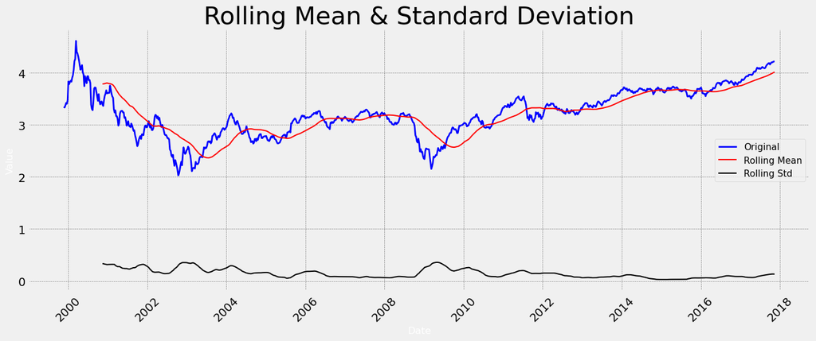

```
Results of Dickey-Fuller Test:
Test Statistic                  -1.527613
p-value                          0.519810
#Lags Used                       4.000000
Number of Observations Used    934.000000
Critical Value (1%)             -3.437371
Critical Value (5%)             -2.864639
Critical Value (10%)            -2.568420
dtype: float64
```

```python
test_stationarity(np.log(ts_week)) # get log -> Reduce data domain
```

```python
df_log = np.log(ts_week)
```

##### Currently, we only work with df_lod

> Use ACF & PACF to check stationary ( can be used to select d,p,q for the model )

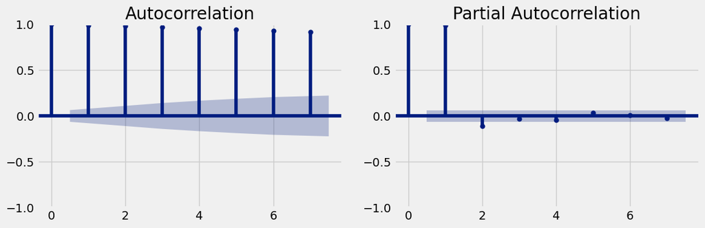

```python
fig, axes = plt.subplots(1, 2)
fig.set_figwidth(12)
fig.set_figheight(4)
smt.graphics.plot_acf(df_log, lags=7, ax=axes[0])
smt.graphics.plot_pacf(df_log, lags=7, ax=axes[1])
plt.tight_layout()
```

> If you don't use the test_stationary function, from the ADF and PACF graphs above, we can see that this data has not eliminated train and seasonal (this data is non-stationary).

> We can determine the best model is (1,1,0) or (0,1,1) from the graph above (you can run a test to know the best model)

> In addition, we can use auto_ARIMA to let the model automatically find the best model!

#### 4. Build ARIMA Model

> Split training and testing (80:20)

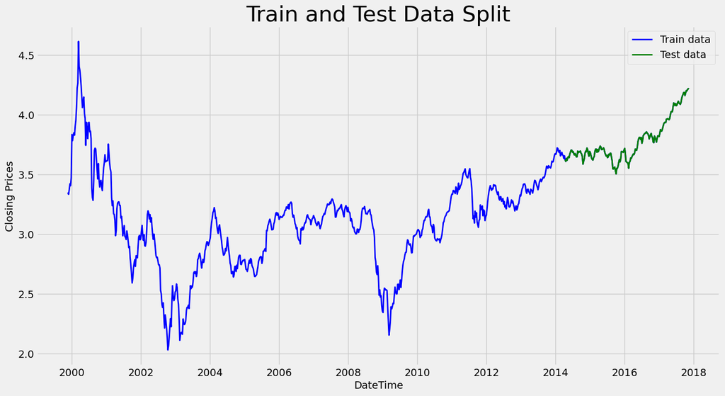

```python
#split data into train and training set
train_data, test_data = df_log[0:int(len(df_log)*0.8)], df_log[int(len(df_log)*0.8):]
plt.figure(figsize=(15,8))
plt.grid(True)
plt.xlabel('DateTime')
plt.ylabel('Closing Prices')
plt.plot(df_log, 'blue', label='Train data',linewidth=2)
plt.plot(test_data, 'green', label='Test data',linewidth=2)
plt.title("Train and Test Data Split", fontsize=30)
plt.legend()
```

> Finding the best parameters (p,q and d)

```python
model_autoARIMA = auto_arima(train_data, start_p=0, start_q=0,
                      test='adf',       # use adftest to find optimal 'd'
                      max_p=3, max_q=3, # maximum p and q
                      m=52,             # frequency of series
                      d=None,           # let model determine 'd'
                      D=1,
                      seasonal= True,
                      start_P=0,
                      trace=True,
                      error_action='ignore',
                      suppress_warnings=True,
                      stepwise=True
                      )
```

```
Performing stepwise search to minimize aic
 ARIMA(0,1,0)(0,1,1)[52]             : AIC=inf, Time=46.35 sec
 ARIMA(0,1,0)(0,1,0)[52]             : AIC=-1595.893, Time=0.57 sec
 ARIMA(1,1,0)(1,1,0)[52]             : AIC=-1827.217, Time=18.01 sec
 ARIMA(0,1,1)(0,1,1)[52]             : AIC=inf, Time=90.46 sec
 ARIMA(1,1,0)(0,1,0)[52]             : AIC=-1624.258, Time=0.38 sec
 ARIMA(1,1,0)(2,1,0)[52]             : AIC=inf, Time=148.20 sec
 ARIMA(1,1,0)(1,1,1)[52]             : AIC=inf, Time=100.35 sec
 ARIMA(1,1,0)(0,1,1)[52]             : AIC=inf, Time=102.24 sec
 ARIMA(1,1,0)(2,1,1)[52]             : AIC=inf, Time=411.69 sec
 ARIMA(0,1,0)(1,1,0)[52]             : AIC=-1809.095, Time=13.57 sec
 ARIMA(2,1,0)(1,1,0)[52]             : AIC=-1825.218, Time=24.05 sec
 ARIMA(1,1,1)(1,1,0)[52]             : AIC=-1825.165, Time=14.66 sec
 ARIMA(0,1,1)(1,1,0)[52]             : AIC=-1827.170, Time=14.15 sec
 ARIMA(2,1,1)(1,1,0)[52]             : AIC=-1823.240, Time=19.60 sec
 ARIMA(1,1,0)(1,1,0)[52] intercept   : AIC=-1825.308, Time=49.67 sec

Best model:  ARIMA(1,1,0)(1,1,0)[52]
Total fit time: 1054.133 seconds
```

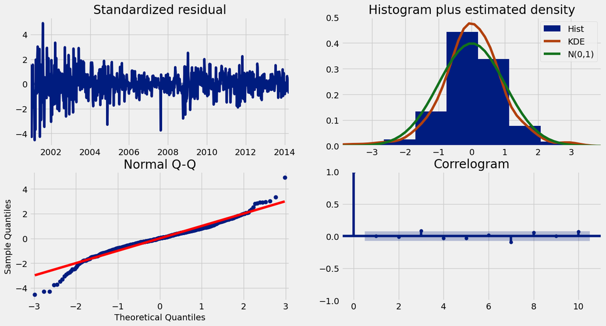

```python
model_autoARIMA.plot_diagnostics(figsize=(15,8))
plt.show()
```

> Using SARIMAX model (this model is "ARIMA plus seasonal")

```python
# Create and train ARIMA model
model = SARIMAX(train_data, order=(2,0,1))
fitted = model.fit()  # Remove the 'disp' parameter
print(fitted.summary())
```

```
RUNNING THE L-BFGS-B CODE

           * * *

Machine precision = 2.220D-16
 N =            4     M =           10

At X0         0 variables are exactly at the bounds

At iterate    0    f= -1.45834D+00    |proj g|=  6.67068D-02

           * * *

Tit   = total number of iterations
Tnf   = total number of function evaluations
Tnint = total number of segments explored during Cauchy searches
Skip  = number of BFGS updates skipped
Nact  = number of active bounds at final generalized Cauchy point
Projg = norm of the final projected gradient
F     = final function value

           * * *

   N    Tit     Tnf  Tnint  Skip  Nact     Projg        F
    4      2      6      1     0     0   3.315D-03  -1.458D+00
  F =  -1.4583430249436222

CONVERGENCE: REL_REDUCTION_OF_F_<=_FACTR*EPSMCH
                               SARIMAX Results
==============================================================================
Dep. Variable:                  Close   No. Observations:                  751
Model:               SARIMAX(2, 0, 1)   Log Likelihood                1095.216
Date:                Thu, 22 Feb 2024   AIC                          -2182.431
Time:                        15:48:37   BIC                          -2163.946
Sample:                    11-21-1999   HQIC                         -2175.309
                         - 04-06-2014
Covariance Type:                  opg
==============================================================================
                 coef    std err          z      P>|z|      [0.025      0.975]
------------------------------------------------------------------------------
ar.L1          1.3787      0.157      8.792      0.000       1.071       1.686
ar.L2         -0.3788      0.157     -2.416      0.016      -0.686      -0.071
ma.L1         -0.2372      0.165     -1.436      0.151      -0.561       0.087
sigma2         0.0031   6.98e-05     44.836      0.000       0.003       0.003
===================================================================================
Ljung-Box (L1) (Q):                   0.00   Jarque-Bera (JB):              2539.53
Prob(Q):                              0.95   Prob(JB):                         0.00
Heteroskedasticity (H):               0.18   Skew:                             0.09
Prob(H) (two-sided):                  0.00   Kurtosis:                        12.01
===================================================================================

Warnings:
[1] Covariance matrix calculated using the outer product of gradients (complex-step).
```

```
 This problem is unconstrained.
```

> Draw a stock price prediction model using sarimax

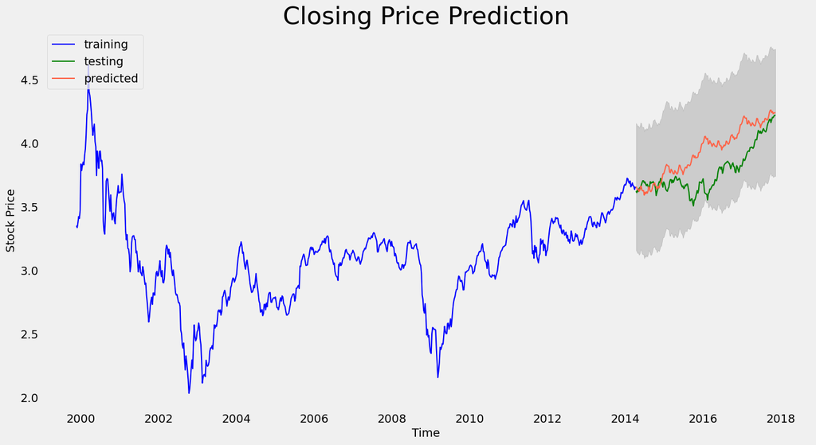

```python
# Predict and calculate confidence intervals
fc, confint = model_autoARIMA.predict(n_periods=len(test_data), return_conf_int=True, conf_int_level=0.9)

# Convert prediction to Pandas Series
fc_series = pd.Series(fc, index=test_data.index)

# Calculate and generate Pandas Series for narrower confidence intervals
margin_of_error = 0.5
lower_series = fc_series - margin_of_error
upper_series = fc_series + margin_of_error

plt.figure(figsize=(15, 8))
# Visualize
plt.plot(train_data, label= 'training', linewidth=1.5, color ='blue')
plt.plot(test_data, label = 'testing', linewidth=1.5,color ='green')
plt.plot(fc_series,label='predicted', linewidth=1.5,color='tomato')
plt.fill_between(lower_series.index, lower_series, upper_series, color='k', alpha =.15)
plt.grid(False)
plt.title('Closing Price Prediction', fontsize=30)
plt.xlabel('Time')
plt.ylabel('Stock Price')
plt.legend(loc='upper left')
plt.show()
```

> The above model gives quite good results!

```python
# Accuracy metrics
def forecast_accuracy(forecast, actual):
    """
    Calculates various accuracy metrics for time series forecasts.

    Args:
        forecast: An array of predicted values.
        actual: An array of actual values.

    Returns:
        A dictionary containing the following accuracy metrics:
            - MAPE: Mean Absolute Percentage Error
            - ME: Mean Error
            - MAE: Mean Absolute Error
            - MPE: Mean Percentage Error
            - RMSE: Root Mean Squared Error
            - Corr: Correlation Coefficient
            - MinMax: Min-Max Normalization Error
    """

    # Ensure correct input shapes
    forecast = np.array(forecast).flatten()
    actual = np.array(actual).flatten()

    # Calculate metrics
    mape = np.mean(np.abs(forecast - actual) / np.abs(actual))  # MAPE
    me = np.mean(forecast - actual)             # ME
    mae = np.mean(np.abs(forecast - actual))    # MAE
    mpe = np.mean((forecast - actual) / actual)   # MPE
    rmse = np.sqrt(np.mean((forecast - actual)**2))  # RMSE
    corr = np.corrcoef(forecast, actual)[0, 1]   # Correlation

    # Min-Max Normalization Error
    mins = np.minimum(forecast, actual)
    maxs = np.maximum(forecast, actual)
    minmax = 1 - np.mean(mins / maxs)

    # Return results in a dictionary
    return {'mape': mape, 'me': me, 'mae': mae, 'mpe': mpe, 'rmse': rmse, 'corr': corr, 'minmax': minmax}

# Example usage:
forecast_accuracy(fc, test_data)
```

```
{'mape': 0.04435620771182591,
 'me': 0.15420772880937325,
 'mae': 0.16572230339247945,
 'mpe': 0.041233109332263713,
 'rmse': 0.20363670961252142,
 'corr': 0.749830621015805,
 'minmax': 0.04158672049800194}
```

#### 5. Smoothing (Using monthly data)

##### Time series Decomposition

##### Case 1: Additive seasonal decomposition

df is monthly data

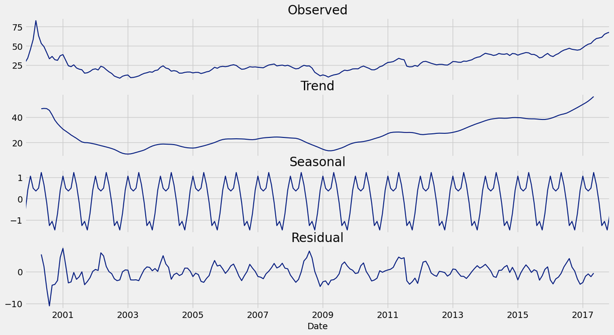

```python
# Perform decomposition
result = seasonal_decompose(df, model='additive')
fig, (ax1, ax2, ax3, ax4) = plt.subplots(4, 1, figsize=(15, 8), sharex=True)

result.observed.plot(ax=ax1, title='Observed',linewidth=1.5,)
result.trend.plot(ax=ax2, title='Trend',linewidth=1.5,)
result.seasonal.plot(ax=ax3, title='Seasonal',linewidth=1.5,)
result.resid.plot(ax=ax4, title='Residual',linewidth=1.5,)
```

##### Case 2: Multiplicative seasonal decomposition

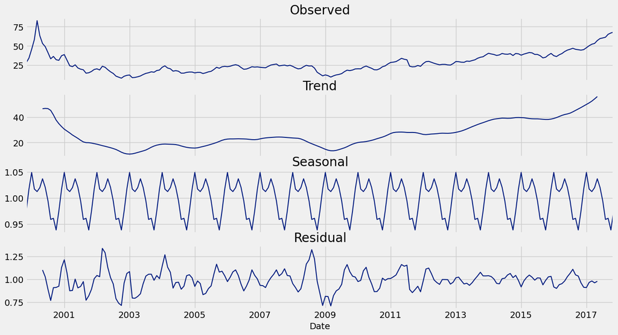

```python
# Perform decomposition
result = seasonal_decompose(df, model='mul')
fig, (ax1, ax2, ax3, ax4) = plt.subplots(4, 1, figsize=(15, 8), sharex=True)

result.observed.plot(ax=ax1, title='Observed',linewidth=1.5,)
result.trend.plot(ax=ax2, title='Trend',linewidth=1.5,)
result.seasonal.plot(ax=ax3, title='Seasonal',linewidth=1.5,)
result.resid.plot(ax=ax4, title='Residual',linewidth=1.5,)
```

##### Simple Exponantial Smoothing

##### Split time series data into training and testing set

```python
df1 = df
```

```python
#split data into train and training set
train_data = df1[0:int(len(df1)*0.8)] # 80:20
test_data = df1[int(len(df1)*0.8):]
```

```python
model = SimpleExpSmoothing(train_data)
model_fit = model.fit(smoothing_level=0.2,optimized=False)
model_fit.params
```

```
{'smoothing_level': 0.2,
 'smoothing_trend': None,
 'smoothing_seasonal': None,
 'damping_trend': nan,
 'initial_level': 28.262375,
 'initial_trend': nan,
 'initial_seasons': array([], dtype=float64),
 'use_boxcox': False,
 'lamda': None,
 'remove_bias': False}
```

```python
y_hat_ses = test_data.copy()
y_hat_ses = model_fit.forecast(24)
```

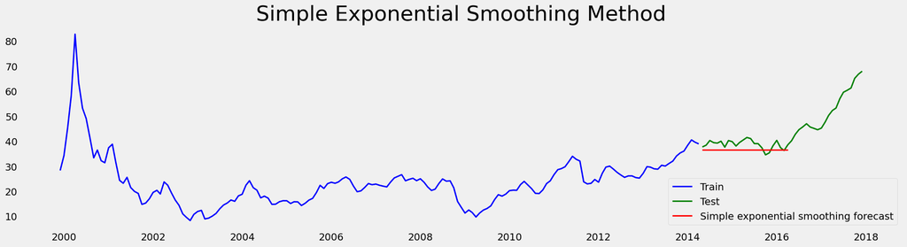

```python
plt.figure(figsize=(20,5))
plt.grid()
plt.plot(train_data, label='Train', color='blue', linewidth = 2)
plt.plot(test_data, label='Test',color='green',linewidth = 2)
plt.plot(y_hat_ses, label='Simple exponential smoothing forecast',color='red',linewidth = 2)
plt.legend(loc='best')
plt.title('Simple Exponential Smoothing Method',fontsize = 30)
plt.show()
```

```python
results = pd.DataFrame(columns=['Method', 'RMSE', 'MAPE'])
```

```python
rmse = np.sqrt(mean_squared_error(test_data[:24], y_hat_ses)).round(2)
mape = np.round(np.mean(np.abs(test_data[:24]-y_hat_ses)/test_data[:24])*100,2)
```

```python
tempResults = pd.DataFrame({'Method':['Simple exponential smoothing forecast'], 'RMSE': [rmse],'MAPE': [mape] })
results = pd.concat([results, tempResults])
results
```

|  | Method | RMSE | MAPE |
| --- | --- | --- | --- |
| 0 | Simple exponential smoothing forecast | 2.75 | 6.25 |

##### Holt's Exponantial Smoothing

```python
train= df[0:int(len(df)*0.8)] # 80:20
test = df[int(len(df)*0.8):]
```

```python
from statsmodels.tsa.holtwinters import ExponentialSmoothing, SimpleExpSmoothing, Holt

model = ExponentialSmoothing(train ,seasonal_periods= 12,trend='add', seasonal=None)
model_fit = model.fit(smoothing_level=0.2, smoothing_slope=0.01, optimized=False)
print(model_fit.params)
```

```
{'smoothing_level': 0.2, 'smoothing_trend': 0.01, 'smoothing_seasonal': None, 'damping_trend': nan, 'initial_level': 46.33726236639025, 'initial_trend': 0.46959797679160886, 'initial_seasons': array([], dtype=float64), 'use_boxcox': False, 'lamda': None, 'remove_bias': False}
```

```python
y_hat_holt = test.copy()
y_hat_holt = model_fit.forecast(len(test))
```

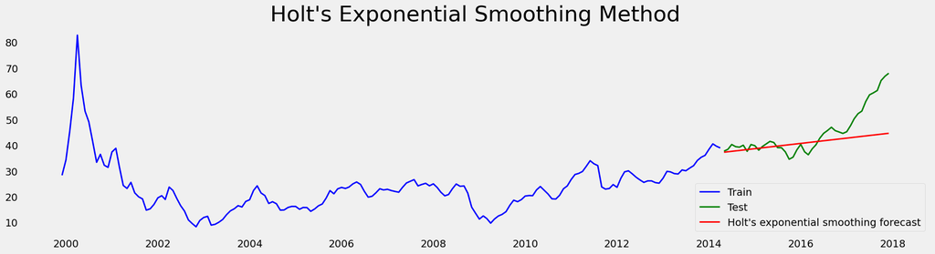

```python
plt.figure(figsize=(20,5))
plt.grid()
plt.plot(train, label='Train', color='blue', linewidth = 2)
plt.plot(test, label='Test',color='green', linewidth = 2)
plt.plot(y_hat_holt, label='Holt\'s exponential smoothing forecast',color='red', linewidth = 2)
plt.legend(loc='best')
plt.title('Holt\'s Exponential Smoothing Method', fontsize = 30)
plt.show()
```

```python
rmse = np.sqrt(mean_squared_error(test[:len(test)], y_hat_holt)).round(2)
mape = np.round(np.mean(np.abs(test[:len(test)]-y_hat_holt)/test[:len(test)])*100,2)
```

```python
tempResults = pd.DataFrame({'Method':['Holt\'s exponential smoothing forecast'], 'RMSE': [rmse],'MAPE': [mape] })
results = pd.concat([results, tempResults])
results
```

|  | Method | RMSE | MAPE |
| --- | --- | --- | --- |
| 0 | Simple exponential smoothing forecast | 2.75 | 6.25 |
| 0 | Holt's exponential smoothing forecast | 8.18 | 10.10 |

##### Holt Winter's Exponential Smoothing - Additive Method

```python
model = ExponentialSmoothing(train ,seasonal_periods=12, trend='add', seasonal='add')
model_fit = model.fit(optimized=True)
print(model_fit.params)
```

```
{'smoothing_level': 0.9999999850988388, 'smoothing_trend': 0.0, 'smoothing_seasonal': 5.082068997685626e-09, 'damping_trend': nan, 'initial_level': 31.617400667238694, 'initial_trend': 0.03546099986473271, 'initial_seasons': array([-3.39057102, -1.91622773, -0.21761313, -0.10766591,  1.1401323 ,
       -0.10446363, -0.62097793, -1.41853087, -2.45110018, -3.7651778 ,
       -3.43321838, -3.92731335]), 'use_boxcox': False, 'lamda': None, 'remove_bias': False}
```

```python
y_hat_hwa = test.copy()
forecast_values = model_fit.forecast(len(test))
y_hat_hwa = forecast_values
```

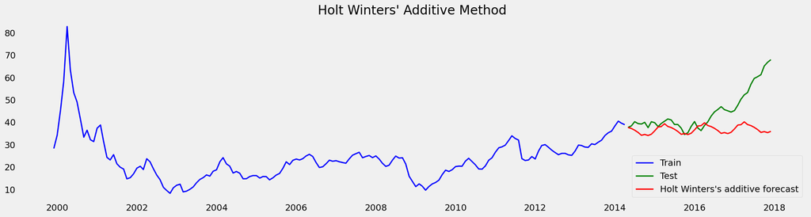

```python
plt.figure(figsize=(20,5))
plt.grid()
plt.plot( train, label='Train',color='blue',linewidth = 2)
plt.plot(test, label='Test',color='green',linewidth = 2)
plt.plot(y_hat_hwa, label='Holt Winters\'s additive forecast',color='red', linewidth = 2)
plt.legend(loc='best')
plt.title('Holt Winters\' Additive Method')
plt.show()
```

```python
rmse = np.sqrt(mean_squared_error(test[:len(test)], y_hat_hwa)).round(2)
mape = np.round(np.mean(np.abs(test[:len(test)] - y_hat_hwa)/test[:len(test)])*100,2)
```

```python
tempResults = pd.DataFrame({'Method':['Holt Winter\'s additive method'], 'RMSE': [rmse],'MAPE': [mape] })
results = pd.concat([results, tempResults])
results
```

|  | Method | RMSE | MAPE |
| --- | --- | --- | --- |
| 0 | Simple exponential smoothing forecast | 2.75 | 6.25 |
| 0 | Holt's exponential smoothing forecast | 8.18 | 10.10 |
| 0 | Holt Winter's additive method | 12.01 | 15.88 |

##### Holt Winter's Exponential Smoothing - Multiplicative Method

```python
model = ExponentialSmoothing(train ,seasonal_periods=12, trend='add', seasonal='mul')
model_fit = model.fit(optimized=True)
print(model_fit.params)
```

[output not shown]

```python
y_hat_hwa = test.copy()
forecast_values = model_fit.forecast(len(test))
y_hat_hwa = forecast_values
```

[figure not shown]

```python
plt.figure(figsize=(20,5))
plt.grid()
plt.plot( train, label='Train',color='blue',linewidth = 2)
plt.plot(test, label='Test',color='green',linewidth = 2)
plt.plot(y_hat_hwa, label='Holt Winters\'s additive forecast',color='red', linewidth = 2)
plt.legend(loc='best')
plt.title('Holt Winters\' Additive Method')
plt.show()
```

```python
rmse = np.sqrt(mean_squared_error(test[:len(test)], y_hat_hwa)).round(2)
mape = np.round(np.mean(np.abs(test[:len(test)] - y_hat_hwa)/test[:len(test)])*100,2)
```

```python
tempResults = pd.DataFrame({'Method':['Holt Winter\'s multiplicative method'], 'RMSE': [rmse],'MAPE': [mape] })
results = pd.concat([results, tempResults])
results
```

|  | Method | RMSE | MAPE |
| --- | --- | --- | --- |
| 0 | Simple exponential smoothing forecast | 2.75 | 6.25 |
| 0 | Holt's exponential smoothing forecast | 8.18 | 10.10 |
| 0 | Holt Winter's additive method | 12.01 | 15.88 |
| 0 | Holt Winter's multiplicative method | 14.85 | 21.42 |

#### 6. RandomForest

> This is an algorithm developed from the decision tree

> This algorithm is difficult or impossible to explain because there is a random factor when selecting nodes in the decision tree

> This algorithm produces better results than ARIMA and ETS

```python
df_log=np.log(ts_week)
# using weekly data
```

```python
N_STEPS = 7
N_FEATURES = 1

def split_time_series(time_series, n_steps=N_STEPS):
    X, y = list(), list()
    for i in range(len(time_series)):
        end_idx = i + n_steps
        if end_idx > len(time_series) - 1:
            break
        seg_X, seg_y = time_series[i:end_idx], time_series[end_idx]
        X.append(seg_X)
        y.append(seg_y)
    return np.array(X), np.array(y)
```

```python
X, y = split_time_series(df_log)
X_train, X_test = X[0:int(len(df_log)*0.8)], X[int(len(df_log)*0.8):]
y_train, y_test = y[0:int(len(df_log)*0.8)], y[int(len(df_log)*0.8):]
```

> Dividing the data set into x_train, x_test, y_train, y_test is an important step in the process of training and evaluating the RF model, helping to ensure the efficiency, objectivity and reliability of the model.

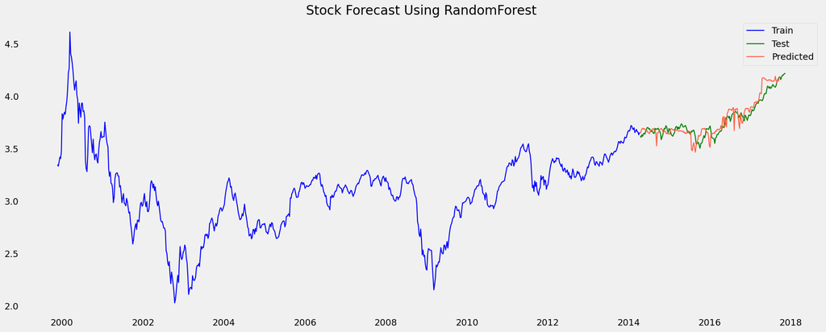

```python
train_data, test_data = df_log[0:int(len(df_log)*0.8)], df_log[int(len(df_log)*0.8):]
rf = RandomForestRegressor(n_estimators=100)
rf.fit(X_train, y_train)
y_rf_forecast = rf.predict(X_test)
rf_forecast_series = pd.Series(y_rf_forecast, index=test_data[:-7].index)

plt.figure(figsize=(20,8))
plt.grid()
plt.plot(train_data,label="Train" ,linewidth = 1.5, color ='blue')
plt.plot(test_data, label="Test",linewidth = 1.5, color ='green')
plt.plot(rf_forecast_series, label="Predicted",linewidth=1.5, color ="tomato")
plt.title("Stock Forecast Using RandomForest")
plt.legend(loc="best")
plt.show()
```

> Based on the graph above, we see that the stock prediction results are better than previous algorithms. But it should be noted that it is susceptible to the Overfitting problem!

#### 7. LSTM

```python
df_log=np.log(ts_week)
# using weekly data
```

```python
N_STEPS = 7
N_FEATURES = 1

def split_time_series(time_series, n_steps=N_STEPS):
    X, y = list(), list()
    for i in range(len(time_series)):
        end_idx = i + n_steps
        if end_idx > len(time_series) - 1:
            break
        seg_X, seg_y = time_series[i:end_idx], time_series[end_idx]
        X.append(seg_X)
        y.append(seg_y)
    return np.array(X), np.array(y)
```

```python
X, y = split_time_series(df_log)
X_train, X_test = X[0:int(len(df_log)*0.8)], X[int(len(df_log)*0.8):]
y_train, y_test = y[0:int(len(df_log)*0.8)], y[int(len(df_log)*0.8):]
```

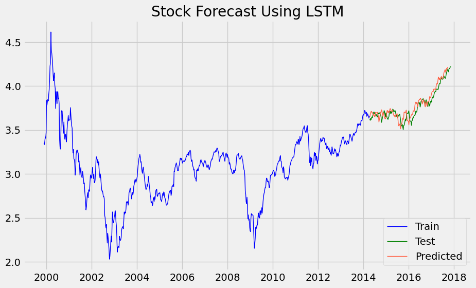

```python
X_train = X_train.reshape((X_train.shape[0], X_train.shape[1], N_FEATURES))
lstm_model = Sequential()
lstm_model.add(LSTM(100, activation='relu'))
lstm_model.add(Dense(N_FEATURES))
lstm_model.compile(optimizer='adam', loss='mse')
lstm_model.fit(X_train, y_train, epochs=250, verbose=0)

X_test = X_test.reshape((X_test.shape[0], X_test.shape[1], N_FEATURES))
y_lstm_forecast = lstm_model.predict(X_test, verbose=0)

train_data, test_data = df_log[0:int(len(df_log)*0.8)], df_log[int(len(df_log)*0.8):]
lstm_forecast_series = pd.Series(y_lstm_forecast.reshape(-1, ), index=test_data[:-7].index)
plt.plot(train_data, linewidth=1, label ="Train", color ="blue")
plt.plot(test_data, linewidth=1, label ="Test", color="green")
plt.plot(lstm_forecast_series, linewidth=1, color = "tomato",label="Predicted")
plt.legend(loc="best")
plt.title("Stock Forecast Using LSTM")
plt.show()
```

#### Conclude:

##### Depending on your purpose, choose the appropriate model

##### If you want to explain using a model, you should choose the ARIMA/SARIMA model

##### If you want to use the model to get the best prediction results, the RandomForest and LSTM models will be the best choice.